# Group_Report3_ModelBuilding

2025-11-27

```r
data <- read.csv("G:/My Drive/2025 - 2026 Year (2nd Year)/Fall 2025/STAT170/cox-violent-parsed.csv")
library(tidyverse)
library(car)
```

### Representative Model

```r
set.seed(862384959)
n <- nrow(data)
train_index <- sample(1:n, size = 0.7 * n)
train_data <- data[train_index, ]
test_data  <- data[-train_index, ]

variablesOfInterest <- c("is_recid", "race", "age", "priors_count", "sex", "decile_score", "juv_fel_count")
df <- train_data[, variablesOfInterest]

model4 <- lm(is_recid ~ race + age + I(age^2) + priors_count + I(priors_count^2) + juv_fel_count + decile_score + I(decile_score^2), data = train_data)
summary(model4)
```

```
##
## Call:
## lm(formula = is_recid ~ race + age + I(age^2) + priors_count +
##     I(priors_count^2) + juv_fel_count + decile_score + I(decile_score^2),
##     data = train_data)
##
## Residuals:
##      Min       1Q   Median       3Q      Max
## -1.47157 -0.37366 -0.06567  0.48024  1.03377
##
## Coefficients:
##                       Estimate Std. Error t value Pr(>|t|)
## (Intercept)          7.623e-01  5.455e-02  13.974  < 2e-16 ***
## raceAsian           -7.207e-02  7.609e-02  -0.947 0.343569
## raceCaucasian        1.088e-02  1.091e-02   0.997 0.318618
## raceHispanic        -4.878e-02  1.793e-02  -2.721 0.006522 **
## raceNative American -8.391e-02  8.107e-02  -1.035 0.300691
## raceOther            5.138e-03  2.281e-02   0.225 0.821829
## age                 -2.779e-02  2.618e-03 -10.616  < 2e-16 ***
## I(age^2)             2.498e-04  3.171e-05   7.877 3.62e-15 ***
## priors_count         6.780e-02  2.343e-03  28.939  < 2e-16 ***
## I(priors_count^2)   -1.786e-03  9.765e-05 -18.293  < 2e-16 ***
## juv_fel_count        2.094e-04  1.070e-02   0.020 0.984396
## decile_score         2.650e-02  7.387e-03   3.587 0.000335 ***
## I(decile_score^2)   -1.357e-03  6.565e-04  -2.067 0.038782 *
## ---
## Signif. codes:  0 '***' 0.001 '**' 0.01 '*' 0.05 '.' 0.1 ' ' 1
##
## Residual standard error: 0.5294 on 12808 degrees of freedom
## Multiple R-squared:  0.1557, Adjusted R-squared:  0.1549
## F-statistic: 196.8 on 12 and 12808 DF,  p-value: < 2.2e-16
```

Our representative model includes curvature terms for age, priors_count, and decile_score in addition to race and juv_fel_count. The curvature terms for age, priors_count, and decile_score are all statistically significant, indicating important nonlinear effects on recidivism. Race coefficients are mostly not significant, suggesting if there is direct association after adjusting for criminal history. The adjusted R^2 of 0.1549 shows a decent explanation of variability.

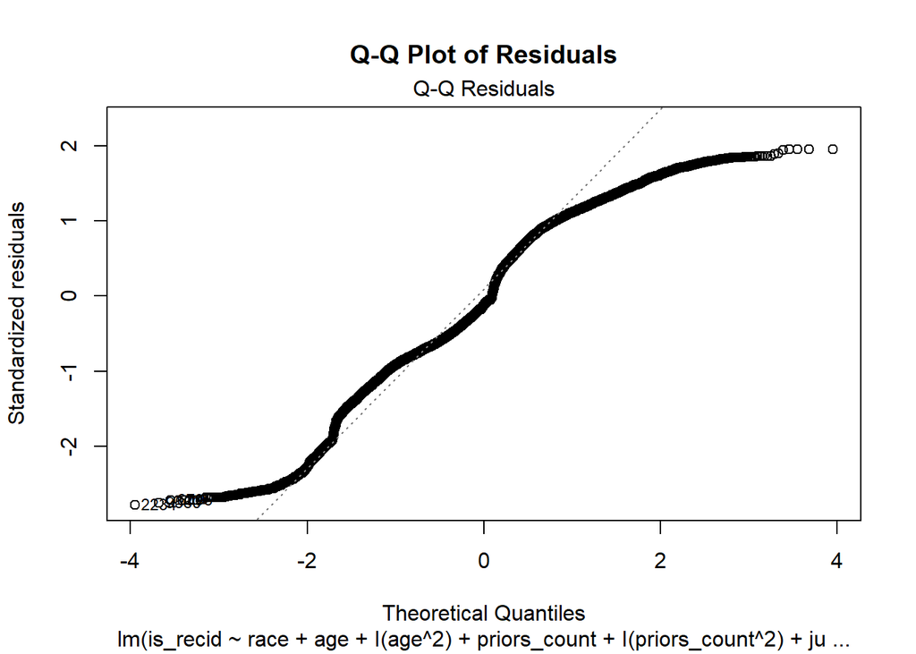

```r
plot(model4, which = 2, main = "Q-Q Plot of Residuals")
```

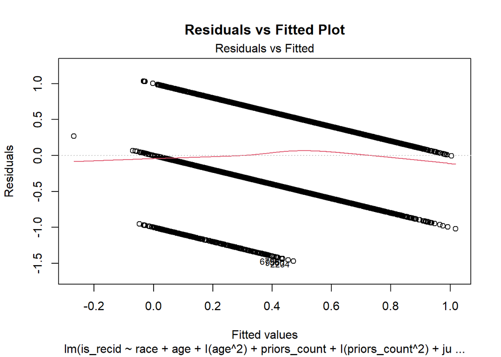

```r
plot(model4, which = 1, main = "Residuals vs Fitted Plot")
```

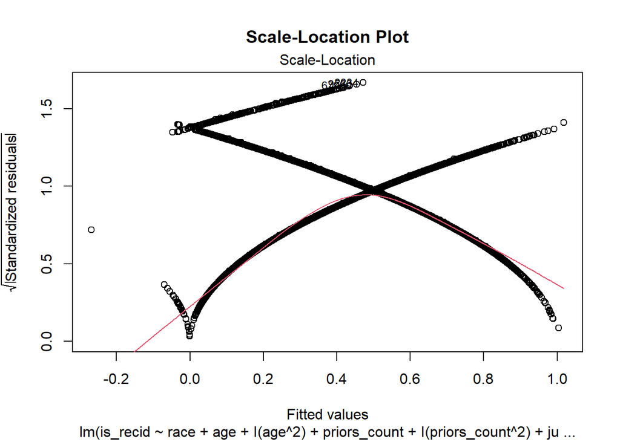

```r
plot(model4, which = 3, main = "Scale-Location Plot")
```

### Comparison

Member - Model Type - Adjusted R^2 - RMSE Test Output

Ali - Curvature only - 0.1549 - 0.5285 - Best predictive performance

Shrey - Interactions - 0.1587 - 0.5854

Wasim - Interactions - 0.1595 - 0.5431

Usman - Curvature only - 0.4257 - 2.263

### Group Discussion & Synthesis

Ali’s model had the lowest test RMSE at 0.5285, indicating the strongest performance, even though the adjusted R^2 was slightly lower than the rest. Shrey and Wasim achieved slightly higher adjusted R^2 values, however, but both models performed worse on the test set.

Interaction terms also introduced more complexity and multicollinearity concerns for those models. Race effects were weak or inconsistent across members. RMSE comparisons also show that nonlinear patterns in age and priors_count are meaningful predictors of recidivism risk.

As a group, we learned that added complexity doesn’t always improve prediction and should be supported by statistical significance and diagnostics. Next steps should include exploring alternative nonlinear methods.